# Translation Elicitation

## Random effects

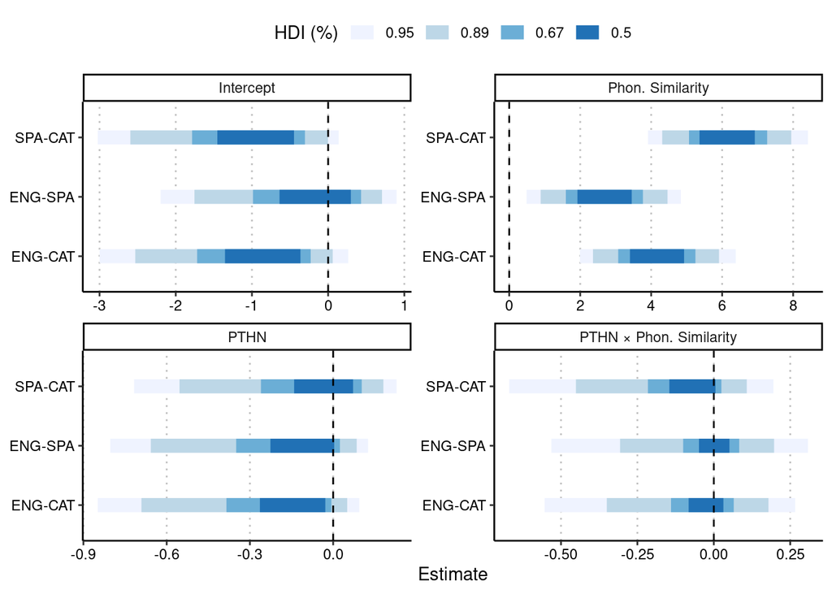

Group-level effects. We specified a maximal random effects structure. As a result, intercepts and slopes were estimated for each group. This figure shows how the estimated intercepts and slopes varied across groups. There are not any remarkable differences across groups, except for the slope of phonological similarity. The accuracy of Spanish-native speakers translating from Catala (SPA-CAT) was slightly boosted by the phonological similarity between translation equivalents in comparison with the rest of the groups (ENG-SPA and ENG-CAT).

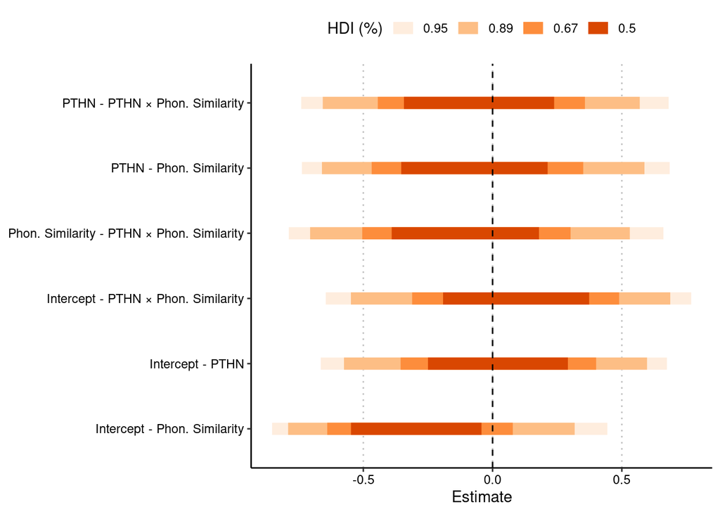

Pairwise correlations between group-level effects. This figure displays the correlation between the posterior draws of all pairs of coefficients in the random effects structure. All 95% HDI of the correlation included zero, and no remarkable differences can be found across groups.

[^1]: We originally planned to exclude participants that reported any visual impairment that glasses would not correct. This item was phrased as *Do you have normal or corrected-to-normal VISION? (Yes/No)* in English, and as *¿Tienes problemas de VISIÓN que unas gafas o lentes de contacto NO corrijan? (Sí/No)*. Surprisingly, the proportion of Spanish participants that reported visual impairment was implausibly large (*n* = 6, 18.18%). This is possibly due to some participants using glasses daily and not having read the item until the end, where it is indicated that the use of glasses is considered as normal vision.